# stack

**definisi stack** Stacks adalah satu struktur data dimana penambahan dan penghapusan data, hanya dapat dilakukan pada satu ujung yang sama, atau yang biasa dikenal dengan istilah top. Semakin data jauh berada dari posisi top, maka data tersebut diindikasikan berada di stack lebih lama dibandingkan dengan data yang berada dekat pada data di posisi top. Jika terdapat data baru yang ditambahkan di stack, maka data ini pulalah yang akan dihapus ketika terdapat proses penghapusan data. Konsep ini dikenal dengan nama LIFO-Last In First Out.

Konsep stack ini dapat ditemui pada permasalahan sehari-hari, misalkan tumpukan buku pada Gambar 1 berikut.

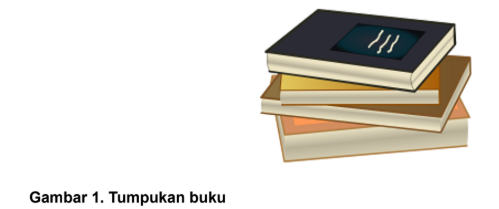

Jika kita ingin mengambil buku pada tumpukan buku tersebut, maka buku yang dapat kita ambil adalah buku yang berada di posisi teratas. Jika ingin mengambil buku yang berada di posisi paling bawah, maka kita harus mengambil buku-buku yang berada di posisi atasnya terlebih dahulu. Begitu juga ketika terdapat penambahan buku baru, maka buku baru ini akan berada di posisi paling atas. Operasi pada Stacks Terdapat operasi dasar pada Stacks,

- stack (), inisialisasi stack yang kosong
- push(data), penambahan data baru pada posisi top dari stack
- pop(), penghapusan data yang terdapat di posisi top dari stack. R eturn value dari fungsi ini adalah data yang dihapus dari stack tersebut
- peek(), informasi data yang terletak pada posisi top
- isEmpty(), untuk memeriksa apakah stack dalam keadaan kosong
- size(), informasi jumlah data yang terdapat pada stack

Ilustrasi proses penambahan data atau yang dikenal dengan istilah push dapat dilihat pada Gambar 2 berikut.

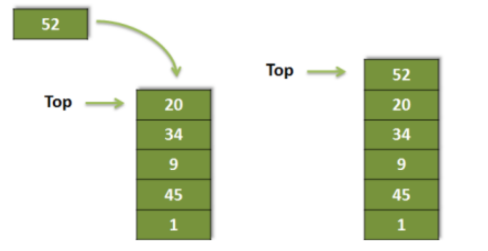

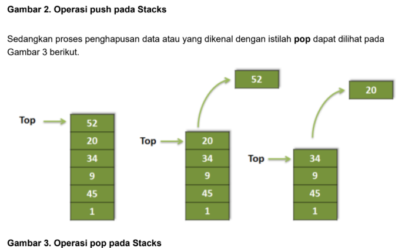

Code

Berikut adalah fungsi-fungsi yang dibutuhkan untuk mengimplementasikan stacks.

```python
def stack():
    s=[]
    return (s)
def push(s,data):
    s.append(data)
def pop(s):
    data=s.pop()
    return(data)
def peek(s):
    return(s[len(s)-1])
def isEmpty(s):
    return (s==[])
def size(s):
    return(len(s))
```

```python
def Erick():
    return []

def push(stack, data):
    stack.append(data)

def pop(stack):
    if stack != []:
        return stack.pop()
    else:
        print("Stack kosong!")
        return None

def peek(stack):
    if stack != []:
        return stack[-1]
    else:
        print("Stack kosong!")
        return None

def isEmpty(stack):
    return stack == []

def size(stack):
    return len(stack)

data = Erick()

push(data, 'e')
push(data, 'r')
push(data, 'i')
push(data, 'k')


print("Isi stack:", data)
print("Pop:", pop(data))
print("Peek:", peek(data))
print("Size:", size(data))
print("Is Empty:", isEmpty(data))
```

```
Isi stack: ['e', 'r', 'i', 'k']
Pop: k
Peek: i
Size: 3
Is Empty: False
```

```python
stack=[]
stack.append('a')
stack.append('b')
stack.append('c')
print('isi stack setelah push ',stack)
datakeluar=stack.pop()
print("data yang di-pop ",datakeluar)
print('data teratas (peek): ',stack[-1])
print('apakah stack kosong?',len(stack)==0)
```

```
isi stack setelah push  ['a', 'b', 'c']
data yang di-pop  c
data teratas (peek):  b
apakah stack kosong? False
```

```python
def ktk():
    return []

def push(stack, data):
    stack.append(data)

def pop(stack):
    if stack != []:
        return stack.pop()
    else:
        print("Stack kosong!")
        return None

def cek(kata):
    stack=ktk()

    for i in kata:
        push(stack, i)
    for i in kata:
        if i != pop(stack):
            return False
    return True

def size(stack):
    return len(stack)

data = ktk()

push(data, 'e')
push(data, 'r')
push(data, 'i')
push(data, 'k')


print("Isi stack:", data)
print("Pop:", pop(data))
print("Peek:", peek(data))
print("Size:", size(data))
print("Is Empty:", isEmpty(data))
```

```
Isi stack: ['e', 'r', 'i', 'k']
Pop: k
Peek: i
Size: 3
Is Empty: False
```

```python
stack = []

# append() function to push element in the stack
stack.append('a')
stack.append('b')
stack.append('c')

print('Initial stack')
print(stack)
# pop() function to pop element from stack in LIFO order
print('\nElements popped from stack:')
print(stack.pop())
print(stack.pop())
print(stack.pop())

print('\nStack after elements are popped:')
print(stack)

# uncommenting print(stack.pop()) will cause an IndexError as the stack is now empty
```

```
Initial stack
['a', 'b', 'c']

Elements popped from stack:
c
b
a

Stack after elements are popped:
[]
```

```python
# Buatlah fungsi untuk mengecek apakah suatu string merupakan palindrome menggunakan stack.
# Input: "KATAK"
# Output: Palindrome

def cek_palindrome(kata):
    stack = []

    # Masukkan semua huruf ke stack
    for huruf in kata:
        stack.append(huruf)

    # Bandingkan dengan pop dari stack
    for huruf in kata:
        if huruf != stack.pop():
            return "Bukan Palindrome"
    return "Palindrome"

# Input
kata = "KATAK"

# Output
print("Input:", kata)
print("Output:", cek_palindrome(kata))
```

```
Input: KATAK
Output: Palindrome
```

```python
 # Buatlah fungsi untuk mengecek apakah suatu string merupakan palindrome menggunakan stack.
# Input: "KATAK"
# Output: Palindrome
kata = "KATAK"
stack = []

for huruf in kata:
    stack.append(huruf)

palindrome = True

for huruf in kata:
    if huruf != stack.pop():
        palindrome = False
        break

print("Input:", kata)

if palindrome:
    print("Output: Palindrome")
else:
    print("Output: Bukan Palindrome")
```

```
Input: KATAK
Output: Palindrome
```

Riwayat Undo (Simulasi Undo Text Editor)

Buatlah program sederhana untuk mensimulasikan fitur Undo pada editor teks.

Ketentuan:

User memasukkan beberapa teks.

Setiap input disimpan ke dalam stack.

Jika user mengetik UNDO, maka teks terakhir dihapus.

Contoh:

Input: Halo

Input: Dunia

Input: Belajar Stack

Input: UNDO

Output: Dunia

```python
stack = []

while True:
    teks = input("Input (ketik STOP untuk selesai): ")

    if teks == "STOP":
        break

    elif teks == "UNDO":
        if len(stack) > 0:
            stack.pop()
            print("undo berhasil.")
        else:
            print("Tidak ada yang bisa di-undo.")

    else:
        stack.append(teks)

if len(stack) > 0:
    print("Output:", stack[-1])
else:
    print("Output: (Kosong)")
```

```
undo berhasil.
```

```
Output: aku
```

```python
parkiran = []
maks = 5

def masuk_mobil(nopol):
    if len(parkiran) >= maks:
        print("Parkiran penuh!")
    else:
        parkiran.append(nopol)
        print(f"Mobil {nopol} masuk parkiran")

def keluar_mobil():
    if len(parkiran) == 0:
        print("Parkiran kosong!")
    else:
        mobil = parkiran.pop()
        print(f"Mobil {mobil} keluar parkiran")

def tampilkan():
    if len(parkiran) == 0:
        print("Parkiran kosong")
    else:
        print("Isi parkiran (LIFO):")
        for mobil in reversed(parkiran):
            print(mobil)

# Menu
while True:
    print("\n=== PARKIRAN MOBIL ===")
    print("1. Mobil Masuk")
    print("2. Mobil Keluar")
    print("3. Tampilkan Parkiran")
    print("4. Keluar")

    pilih = input("Pilih menu: ")

    if pilih == "1":
        nopol = input("Masukkan nomor mobil: ")
        masuk_mobil(nopol)
    elif pilih == "2":
        keluar_mobil()
    elif pilih == "3":
        tampilkan()
    elif pilih == "4":
        print("Program selesai")
        break
    else:
        print("Pilihan tidak valid!")
```

```
=== PARKIRAN MOBIL ===
1. Mobil Masuk
2. Mobil Keluar
3. Tampilkan Parkiran
4. Keluar
```

```
Mobil 2 masuk parkiran

=== PARKIRAN MOBIL ===
1. Mobil Masuk
2. Mobil Keluar
3. Tampilkan Parkiran
4. Keluar
```

```
Isi parkiran (LIFO):
2

=== PARKIRAN MOBIL ===
1. Mobil Masuk
2. Mobil Keluar
3. Tampilkan Parkiran
4. Keluar
```

```
Mobil 2 keluar parkiran

=== PARKIRAN MOBIL ===
1. Mobil Masuk
2. Mobil Keluar
3. Tampilkan Parkiran
4. Keluar
```

```
Program selesai
```

# Queues

**Definisi Queues** Queues atau antrian merupakan struktur data dimana penambahan data baru dan penghapusan data berada di ujung yang berbeda. Hal ini berbeda dengan stacks, dimana penambahan data baru dan penghapusan data, dilakukan pada ujung yang sama. Pada Queues, seperti halnya antrian, penambahan data baru dilakukan di suatu ujung atau yang dikenal dengan nama rear, dan penghapusan data dilakukan pada ujung yang dikenal dengan nama front, seperti yang terlihat pada Gambar 1 berikut :

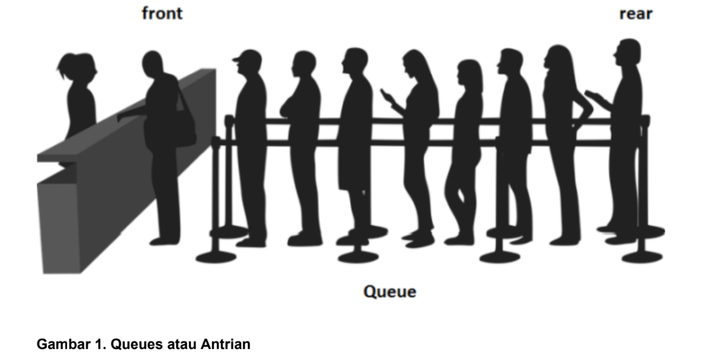

Jika konsep penambahan atau penghapusan data pada stacks dikenal dengan nama LIFO (Last In First Out), maka pada Queues menggunakan konsep FIFO (First In First Out)

Operasi pada Queues Terdapat beberapa operasi dasar pada struktur data Queues ini, antara lain :

- queue (), inisialisasi struktur data queue kosong
- enqueue (data), penambahan *data* baru pada queue
- dequeue (), penghapusan data
- isEmpty(), pengecekan apakah queue dalam keadaan kosong
- size (), informasi jumlah data yang terdapat pada queue

Ilustrasi penambahan dan penghapusan data dapat dilihat pada Gambar 2 dan Gambar 3 berikut :

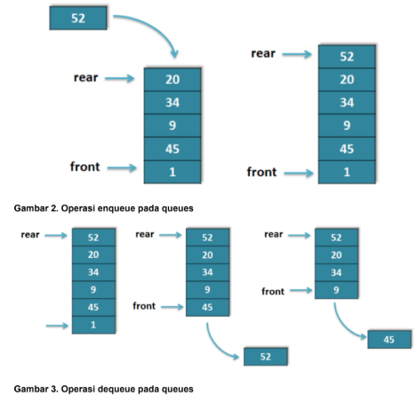

Pada Gambar 2 ditunjukkan bahwa penambahan data baru (enqueue) dilakukan pada ujung data 'rear', sedangkan penghapusan data (dequeque) dilakukan pada ujung data 'front', karena sifat queues yang FIFO.

**Code**

Berikut adalah code-code untuk pembentukan queues dan operasi-operasi yang terdapat pada queues

```python
def createQueue():
    q=[]
    return (q)
def enqueue(q,data):
    q.insert(0,data)
    return(q)
def dequeue(q):
    data=q.pop()
    return(data)
def isEmpty(q):
    return (q==[])
def size(q):
    return (len(q))
```

```python
q=createQueue()
enqueue(q,'matematika')
enqueue(q,'struktur data')
enqueue(q,'bahasa inggris')
enqueue(q,'pemrograman web')
print(q)
```

```
['pemrograman web', 'bahasa inggris', 'struktur data', 'matematika']
```

```python
def ularNaga(nama, hitungan):
    gameQueue = createQueue()
    for namaAnak in nama:
        enqueue(gameQueue,namaAnak)
        print('Peserta Permainan=',gameQueue)
        while size(gameQueue) > 1:
            for i in range(hitungan):
                enqueue(gameQueue,dequeue(gameQueue))
                print('hitungan ke-',i,'=',gameQueue)
            dequeue(gameQueue)
            print('Peserta Permainan=',gameQueue)
        return dequeue(gameQueue)
ularNaga(['andi','rita','sari','anton','rafa','diana','zaki'],2)
```

```
Peserta Permainan= ['andi']
```

```
'andi'
```

# deques

**definisi deques**

Struktur data yang ketiga adalah Deques. Jika pada stacks, penambahan data baru dan penghapusan dilakukan pada ujung yang sama, yaitu top, sedangkan pada queues, penambahan data baru dan penghapusan dilakukan pada ujung yang berbeda, yaitu rear(penambahan data) dan front(penghapusan data). Maka struktur data deques dapat dilakukan di kedua ujung, seperti halnya queues, hanya terdapat sedikit perbedaan. penambahan data dapat dilakukan pada kedua ujung, baik front maupun rear. Begitu juga halnya dengan penghapusan data yang dapat dilakukan pada front maupun rear. Berikut pembahasan pada struktur data Deques:

1. Operasi Queues
2. Contoh Implementasi Deques Operasi Deques Operasi-operasi yang terdapat pada Deques antara lain :
- deque (), inisialisasi struktur data deque kosong
- addFront (data), penambahan data baru di ujung front pada deque
- addRear (data), penambahan data baru di ujung rear pada deque
- removeRear (), penghapusan data pada ujung rear
- removeFront (), penghapusan data pada ujung front
- isEmpty(), pengecekan apakah deque dalam keadaan kosong
- size (), informasi jumlah data yang terdapat pada deque

Struktur data Deques ini direpresentasikan dengan List, dimana: indeks awal list, yaitu indeks ke-0, adalah posisi front pada deques indeks akhir list, yaitu indeks terakhir, adalah posisi rear pada deques Oleh karena itu, penambahan data baru pada posisi front dapat dilakukan dengan method insert() pada posisi ke-0. Sedangkan penambahan data baru pada posisi rear dapat dilakukan dengan method append , yang merupakan penambahan data baru pada list di posisi terakhir. Sedangkan penghapusan data pada posisi front dapat dilakukan dengan method pop() pada posisi ke-0, sedangkan penghapusan data pada posisi rear dilakukan dengan method pop() .

Code

Berikut adalam implementasi deques dengan menggunakan List :

```python
def createDeque():
    d=[]
    return (d)
def addFront(d,data):
    d.insert(0,data)
    return(d)
def addRear(d,data):
    d.append(data)
    return(d)
def removeRear(d):
    data=d.pop()
    return(data)
def removeFront(d):
    data=d.pop(0)
    return(data)
def isEmpty(d):
    return (d==[])
def size(d):
    return (len(d))
```

```python
deq=createDeque()
addFront(deq,'struktur')
addFront(deq,'data')
```

```
['data', 'struktur']
```

```python
addRear(deq,'2018')
addRear(deq,'2019')
addRear(deq,'100')
```

[output not shown]

```python
data=removeFront(deq)
print(data)
print(deq)
```

[output not shown]